# ECON 470 Homework 3.2

## Question 9

A tibble: 4 × 3

| Cutoff <chr> | Characteristic <chr> | Diff <dbl> |
| --- | --- | --- |
| 3.0 stars | HMO | 0.42716545 |
| 3.0 stars | PartD | 0.29107216 |
| 3.5 stars | HMO | -0.22885889 |
| 3.5 stars | PartD | -0.04690552 |

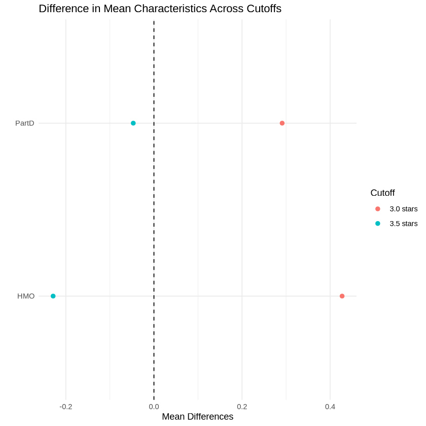

The table and love plot indicate that around 40% more plans are HMOs at the 3-star threshold vs 2.5-stars. Also, plans just above the 3.0 threshold are more likely to have Part D. In contrast, the differences for the 3.5 star threshold are negative but smaller in magnitude. This suggests some differences in HMO and Part D status near the 3-star threshold but not as much evidence of differences at the 3.5 star threshold.